# Laterality of Motivation and Valence

Author

Anonymous

# Laterality of Motivation and Valence, in DLPFC and OFC

**DLPFC**

**Main effects and 2-way interaction**

- Main effect of Motivation?
- Main effect of Valence?
- Interaction of Motivation and Valence?
- Effect of Motivation within each Valence condition?
- Effect of Valence within each Motivation condition?

DLPFC: Main effect of motivation (controlling for valence)

| contrast | estimate | SE | df | lower.CL | upper.CL | t.ratio | p.value |
| --- | --- | --- | --- | --- | --- | --- | --- |
| Approach - Avoidance | −0.041 | 0.034 | 66 | −0.11 | 0.028 | −1.188 | .12 |

p-values are one-sided. A negative number means that approach is more leftward than avoidance.

DLPFC: Main effect of valence (controlling for motivation)

| contrast | estimate | SE | df | lower.CL | upper.CL | t.ratio | p.value |
| --- | --- | --- | --- | --- | --- | --- | --- |
| Positive - Negative | −0.003 | 0.034 | 66 | −0.072 | 0.066 | −0.094 | .463 |

p-values are one-sided.A negative number means that positive valence is more leftward than negative valence.

DLPFC: Interaction of Motivation by Valence (ANOVA model comparison)

| npar | AIC | BIC | logLik | deviance | Chisq | Df | p.value |
| --- | --- | --- | --- | --- | --- | --- | --- |
| 5 | −7.635 | 4.974 | 8.817 | −17.635 | - | - | - |
| 6 | −9.03 | 6.101 | 10.515 | −21.03 | 3.395 | 1 | .033 |

p-values are one-sided.

DLPFC: Interaction of Motivation by Valence (emmeans: compare estimate to zero)

| Motivation_pairwise | Valence_pairwise | estimate | SE | df | lower.CL | upper.CL | t.ratio | p.value |
| --- | --- | --- | --- | --- | --- | --- | --- | --- |
| Approach - Avoidance | Positive - Negative | 0.126 | 0.069 | 66 | −0.012 | 0.264 | 1.825 | .036 |

p-values are one-sided. A positive estimate means that approach vs. avoidance motivation is more leftward than positive vs. negative valence

DLPFC: Effect of Motivation by Valence condition

| contrast | Valence | estimate | SE | df | lower.CL | upper.CL | t.ratio | p.value |
| --- | --- | --- | --- | --- | --- | --- | --- | --- |
| Approach - Avoidance | Positive | 0.022 | 0.049 | 66 | −0.075 | 0.119 | 0.45 | .327 |
| Approach - Avoidance | Negative | −0.104 | 0.049 | 66 | −0.201 | −0.007 | −2.13 | .018 |

p-values are one-sided. A negative number means that approach is more leftward than avoidance.

DLPFC: Effect of Valence by Motivation condition

| contrast | Motivation | estimate | SE | df | lower.CL | upper.CL | t.ratio | p.value |
| --- | --- | --- | --- | --- | --- | --- | --- | --- |
| Positive - Negative | Approach | 0.06 | 0.049 | 66 | −0.038 | 0.157 | 1.224 | .113 |
| Positive - Negative | Avoidance | −0.066 | 0.049 | 66 | −0.164 | 0.031 | −1.356 | .09 |

p-values are one-sided. A negative number means that positive valence is more leftward than negative valence.

**Estimated Asymmetry scores by condition**

Estimate:

- What is the asymmetry score for Approach motivation?
- What is the asymmetry score for Avoidance motivation?
- What is the asymmetry score for Positive Valence?
- What is the asymmetry score for Negative Valence?
- What is the asymmetry score for Approach-Positive?
- What is the asymmetry score for Approach-Negative?
- What is the asymmetry score for Avoid-Positive?
- What is the asymmetry score for Avoid-Negative?

DLPFC: Estimated laterality for Approach and Avoidance

| Motivation | emmean | SE | df | lower.CL | upper.CL | t.ratio | p.value |
| --- | --- | --- | --- | --- | --- | --- | --- |
| Approach | 0.068 | 0.057 | 26.516 | −0.05 | 0.186 | 1.189 | .122 |
| Avoidance | 0.109 | 0.057 | 26.516 | −0.009 | 0.227 | 1.905 | .034 |

p-values are one-sided. A positive estimate means rightward asymmetry

DLPFC: Estimated laterality for Positive and Negative Valence

| Valence | emmean | SE | df | lower.CL | upper.CL | t.ratio | p.value |
| --- | --- | --- | --- | --- | --- | --- | --- |
| Positive | 0.087 | 0.057 | 26.516 | −0.031 | 0.205 | 1.519 | .07 |
| Negative | 0.09 | 0.057 | 26.516 | −0.027 | 0.208 | 1.575 | .064 |

p-values are one-sided. A positive estimate means rightward asymmetry

DLPFC: Estimates for each contrast

| Motivation | Valence | emmean | SE | df | lower.CL | upper.CL | t.ratio | p.value |
| --- | --- | --- | --- | --- | --- | --- | --- | --- |
| Approach | Positive | 0.098 | 0.062 | 36.049 | −0.028 | 0.224 | 1.574 | .062 |
| Avoidance | Positive | 0.076 | 0.062 | 36.049 | −0.05 | 0.202 | 1.221 | .115 |
| Approach | Negative | 0.038 | 0.062 | 36.049 | −0.088 | 0.165 | 0.615 | .271 |
| Avoidance | Negative | 0.142 | 0.062 | 36.049 | 0.016 | 0.268 | 2.284 | .014 |

p-values are one-sided. Positive estimates indicate rightward asymmetry.

Estimate (1 level more granular) - What are the right and left ROI scores for Approach motivation? - What are the right and left ROI scores for Avoidance motivation? - What are the right and left ROI scores for Positive Valence? - What are the right and left ROI scores for Negative motivation?

DLPFC: Estimated mean ROI signal, by side and motivation condition

| Motivation | Side | emmean | SE | df | lower.CL | upper.CL | t.ratio | p.value |
| --- | --- | --- | --- | --- | --- | --- | --- | --- |
| Approach | Left | 0.051 | 0.067 | 45.091 | −0.084 | 0.185 | 0.758 | .452 |
| Avoidance | Left | 0.02 | 0.067 | 45.091 | −0.114 | 0.155 | 0.307 | .761 |
| Approach | Right | 0.119 | 0.067 | 45.091 | −0.016 | 0.253 | 1.778 | .082 |
| Avoidance | Right | 0.13 | 0.067 | 45.091 | −0.005 | 0.264 | 1.939 | .059 |

p-values are two-sided. Positive estimates indicate positive BOLD signal.

DLPFC: Estimated mean ROI signal, by side and valence condition

| Valence | Side | emmean | SE | df | lower.CL | upper.CL | t.ratio | p.value |
| --- | --- | --- | --- | --- | --- | --- | --- | --- |
| Negative | Left | 0.055 | 0.067 | 45.091 | −0.079 | 0.19 | 0.827 | .413 |
| Positive | Left | 0.016 | 0.067 | 45.091 | −0.119 | 0.151 | 0.238 | .813 |
| Negative | Right | 0.145 | 0.067 | 45.091 | 0.011 | 0.28 | 2.177 | .035 |
| Positive | Right | 0.103 | 0.067 | 45.091 | −0.032 | 0.238 | 1.54 | .131 |

p-values are two-sided. Positive estimates indicate positive BOLD signal.

- What are the right and left ROI scores for Approach-Positive?
- What are the right and left ROI scores for Approach-Negative?
- What are the right and left ROI scores for Avoid-Positive?
- What are the right and left ROI scores for Avoid-Negative?

DLPFC: Estimated mean ROI signal, by side, motivation, and valence condition

| Motivation | Valence | Side | emmean | SE | df | lower.CL | upper.CL | t.ratio | p.value |
| --- | --- | --- | --- | --- | --- | --- | --- | --- | --- |
| Approach | Negative | Left | 0.078 | 0.08 | 80.197 | −0.081 | 0.236 | 0.977 | .332 |
| Approach | Negative | Right | 0.116 | 0.08 | 80.197 | −0.042 | 0.274 | 1.458 | .149 |
| Approach | Positive | Left | 0.024 | 0.08 | 80.197 | −0.135 | 0.182 | 0.297 | .767 |
| Approach | Positive | Right | 0.122 | 0.08 | 80.197 | −0.037 | 0.28 | 1.53 | .13 |
| Avoidance | Negative | Left | 0.033 | 0.08 | 80.197 | −0.125 | 0.191 | 0.413 | .681 |
| Avoidance | Negative | Right | 0.175 | 0.08 | 80.197 | 0.017 | 0.333 | 2.201 | .031 |
| Avoidance | Positive | Left | 0.008 | 0.08 | 80.197 | −0.15 | 0.166 | 0.103 | .918 |
| Avoidance | Positive | Right | 0.084 | 0.08 | 80.197 | −0.074 | 0.242 | 1.059 | .293 |

p-values are two-sided. Positive estimates indicate positive BOLD signal.

**OFC**

**Main effects and 2-way interaction**

- Main effect of Motivation?
- Main effect of Valence?
- Interaction of Motivation and Valence?

OFC: Main effect of motivation (controlling for valence)

| contrast | estimate | SE | df | lower.CL | upper.CL | t.ratio | p.value |
| --- | --- | --- | --- | --- | --- | --- | --- |
| Approach - Avoidance | 0 | 0.039 | 66 | −0.077 | 0.077 | −0.004 | .498 |

p-values are one-sided. A negative number means that approach is more leftward than avoidance.

OFC: Main effect of valence (controlling for motivation)

| contrast | estimate | SE | df | lower.CL | upper.CL | t.ratio | p.value |
| --- | --- | --- | --- | --- | --- | --- | --- |
| Positive - Negative | −0.016 | 0.039 | 66 | −0.093 | 0.061 | −0.414 | .34 |

p-values are one-sided.A negative number means that positive valence is more leftward than negative valence.

ofc: Interaction of Motivation by Valence (ANOVA model comparison)

| npar | AIC | BIC | logLik | deviance | Chisq | Df | p.value |
| --- | --- | --- | --- | --- | --- | --- | --- |
| 5 | 12.96 | 25.568 | −1.48 | 2.96 | - | - | - |
| 6 | 9.378 | 24.509 | 1.311 | −2.622 | 5.581 | 1 | .009 |

p-values are one-sided.

OFC: Interaction of Motivation by Valence (emmeans: compare estimate to zero)

| Motivation_pairwise | Valence_pairwise | estimate | SE | df | lower.CL | upper.CL | t.ratio | p.value |
| --- | --- | --- | --- | --- | --- | --- | --- | --- |
| Approach - Avoidance | Positive - Negative | 0.182 | 0.077 | 66 | 0.028 | 0.336 | 2.358 | .011 |

OFC: Effect of Motivation by Valence condition

| contrast | Valence | estimate | SE | df | lower.CL | upper.CL | t.ratio | p.value |
| --- | --- | --- | --- | --- | --- | --- | --- | --- |
| Approach - Avoidance | Positive | 0.091 | 0.055 | 66 | −0.018 | 0.2 | 1.665 | .05 |
| Approach - Avoidance | Negative | −0.091 | 0.055 | 66 | −0.2 | 0.018 | −1.67 | .05 |

p-values are one-sided. A negative number means that approach is more leftward than avoidance.

OFC: Effect of Valence by Motivation condition

| contrast | Motivation | estimate | SE | df | lower.CL | upper.CL | t.ratio | p.value |
| --- | --- | --- | --- | --- | --- | --- | --- | --- |
| Positive - Negative | Approach | 0.075 | 0.055 | 66 | −0.034 | 0.184 | 1.375 | .087 |
| Positive - Negative | Avoidance | −0.107 | 0.055 | 66 | −0.216 | 0.002 | −1.96 | .027 |

p-values are one-sided. A negative number means that positive valence is more leftward than negative valence.

**Estimated Asymmetry scores by condition**

Estimate:

- What is the asymmetry score for Approach motivation?
- What is the asymmetry score for Avoidance motivation?
- What is the asymmetry score for Positive Valence?
- What is the asymmetry score for Negative Valence?
- What is the asymmetry score for Approach-Positive?
- What is the asymmetry score for Approach-Negative?
- What is the asymmetry score for Avoid-Positive?
- What is the asymmetry score for Avoid-Negative?

OFC: Estimated laterality for Approach and Avoidance

| Motivation | emmean | SE | df | lower.CL | upper.CL | t.ratio | p.value |
| --- | --- | --- | --- | --- | --- | --- | --- |
| Approach | 0.009 | 0.061 | 26.991 | −0.117 | 0.134 | 0.139 | .445 |
| Avoidance | 0.009 | 0.061 | 26.991 | −0.117 | 0.135 | 0.142 | .444 |

p-values are one-sided. A positive estimate means rightward asymmetry

OFC: Estimated laterality for Positive and Negative Valence

| Valence | emmean | SE | df | lower.CL | upper.CL | t.ratio | p.value |
| --- | --- | --- | --- | --- | --- | --- | --- |
| Positive | 0.001 | 0.061 | 26.991 | −0.125 | 0.126 | 0.01 | .496 |
| Negative | 0.017 | 0.061 | 26.991 | −0.109 | 0.142 | 0.271 | .394 |

p-values are one-sided. A positive estimate means rightward asymmetry

OFC: Estimates for each contrast

| Motivation | Valence | emmean | SE | df | lower.CL | upper.CL | t.ratio | p.value |
| --- | --- | --- | --- | --- | --- | --- | --- | --- |
| Approach | Positive | 0.046 | 0.067 | 37.533 | −0.09 | 0.182 | 0.686 | .248 |
| Avoidance | Positive | −0.045 | 0.067 | 37.533 | −0.181 | 0.091 | −0.668 | .254 |
| Approach | Negative | −0.029 | 0.067 | 37.533 | −0.165 | 0.107 | −0.432 | .334 |
| Avoidance | Negative | 0.062 | 0.067 | 37.533 | −0.074 | 0.198 | 0.926 | .18 |

p-values are one-sided. Positive estimates indicate rightward asymmetry.

Estimate (1 level more granular) - What are the right and left ROI scores for Approach motivation? - What are the right and left ROI scores for Avoidance motivation? - What are the right and left ROI scores for Positive Valence? - What are the right and left ROI scores for Negative motivation?

OFC: Estimated mean ROI signal, by side and motivation condition

| Motivation | Side | emmean | SE | df | lower.CL | upper.CL | t.ratio | p.value |
| --- | --- | --- | --- | --- | --- | --- | --- | --- |
| Approach | Left | 0.134 | 0.084 | 46.88 | −0.035 | 0.303 | 1.599 | .117 |
| Avoidance | Left | 0.063 | 0.084 | 46.88 | −0.105 | 0.232 | 0.756 | .453 |
| Approach | Right | 0.143 | 0.084 | 46.88 | −0.026 | 0.312 | 1.7 | .096 |
| Avoidance | Right | 0.072 | 0.084 | 46.88 | −0.097 | 0.241 | 0.859 | .395 |

p-values are two-sided. Positive estimates indicate positive BOLD signal.

OFC: Estimated mean ROI signal, by side and valence condition

| Valence | Side | emmean | SE | df | lower.CL | upper.CL | t.ratio | p.value |
| --- | --- | --- | --- | --- | --- | --- | --- | --- |
| Negative | Left | 0.155 | 0.084 | 46.88 | −0.014 | 0.324 | 1.842 | .072 |
| Positive | Left | 0.043 | 0.084 | 46.88 | −0.126 | 0.212 | 0.512 | .611 |
| Negative | Right | 0.171 | 0.084 | 46.88 | 0.002 | 0.34 | 2.04 | .047 |
| Positive | Right | 0.044 | 0.084 | 46.88 | −0.125 | 0.213 | 0.52 | .606 |

p-values are two-sided. Positive estimates indicate positive BOLD signal.

- What are the right and left ROI scores for Approach-Positive?
- What are the right and left ROI scores for Approach-Negative?
- What are the right and left ROI scores for Avoid-Positive?
- What are the right and left ROI scores for Avoid-Negative?

OFC: Estimated mean ROI signal, by side, motivation, and valence condition

| Motivation | Valence | Side | emmean | SE | df | lower.CL | upper.CL | t.ratio | p.value |
| --- | --- | --- | --- | --- | --- | --- | --- | --- | --- |
| Approach | Negative | Left | 0.198 | 0.101 | 84.373 | −0.002 | 0.398 | 1.97 | .052 |
| Approach | Negative | Right | 0.169 | 0.101 | 84.373 | −0.031 | 0.369 | 1.682 | .096 |
| Approach | Positive | Left | 0.07 | 0.101 | 84.373 | −0.13 | 0.27 | 0.7 | .486 |
| Approach | Positive | Right | 0.116 | 0.101 | 84.373 | −0.084 | 0.316 | 1.157 | .25 |
| Avoidance | Negative | Left | 0.111 | 0.101 | 84.373 | −0.089 | 0.311 | 1.106 | .272 |
| Avoidance | Negative | Right | 0.173 | 0.101 | 84.373 | −0.027 | 0.374 | 1.724 | .088 |
| Avoidance | Positive | Left | 0.016 | 0.101 | 84.373 | −0.184 | 0.216 | 0.156 | .877 |
| Avoidance | Positive | Right | −0.029 | 0.101 | 84.373 | −0.229 | 0.171 | −0.289 | .773 |

p-values are two-sided. Positive estimates indicate positive BOLD signal.

**DLPFC vs. OFC**

- Interaction of Region * Motivation
- Interaction of Region * Motivation * Valence

Interaction of Region and Motivation (Averaged Over Valence)

| Region_consec | Motivation_consec | estimate | SE | df | lower.CL | upper.CL | t.ratio | p.value |
| --- | --- | --- | --- | --- | --- | --- | --- | --- |
| Orbital Frontal - Dorsolateral | Avoidance - Approach | −0.041 | 0.054 | 154 | −0.147 | 0.065 | −0.76 | .224 |

p-values are one-sided. Negative Estimates Indicate that approach is more left-lateralized for DLPFC.

Interaction of Region by Motivation by Valence

| Region_consec | Motivation_consec | Valence_consec | estimate | SE | df | lower.CL | upper.CL | t.ratio | p.value |
| --- | --- | --- | --- | --- | --- | --- | --- | --- | --- |
| Orbital Frontal - Dorsolateral | Avoidance - Approach | Negative - Positive | 0.056 | 0.107 | 154 | −0.156 | 0.268 | 0.522 | .301 |

**Plots**

**Asymmetry by condition**

#### DLPFC

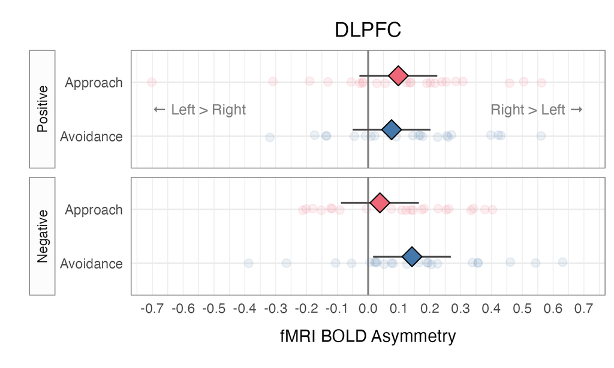

#### OFC

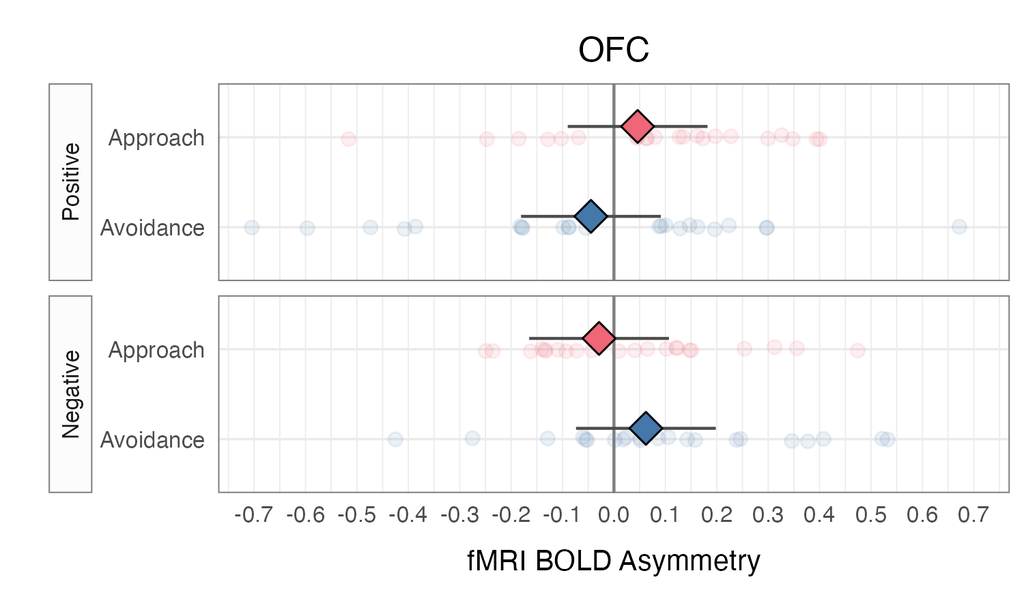

**Plot estimated main effects**

#### DLPFC

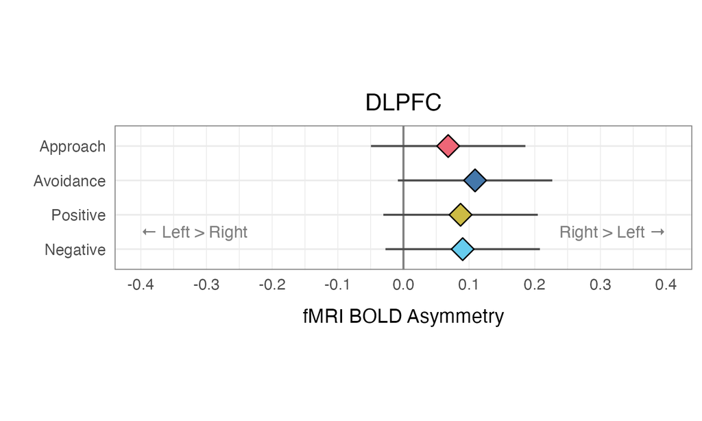

#### OFC

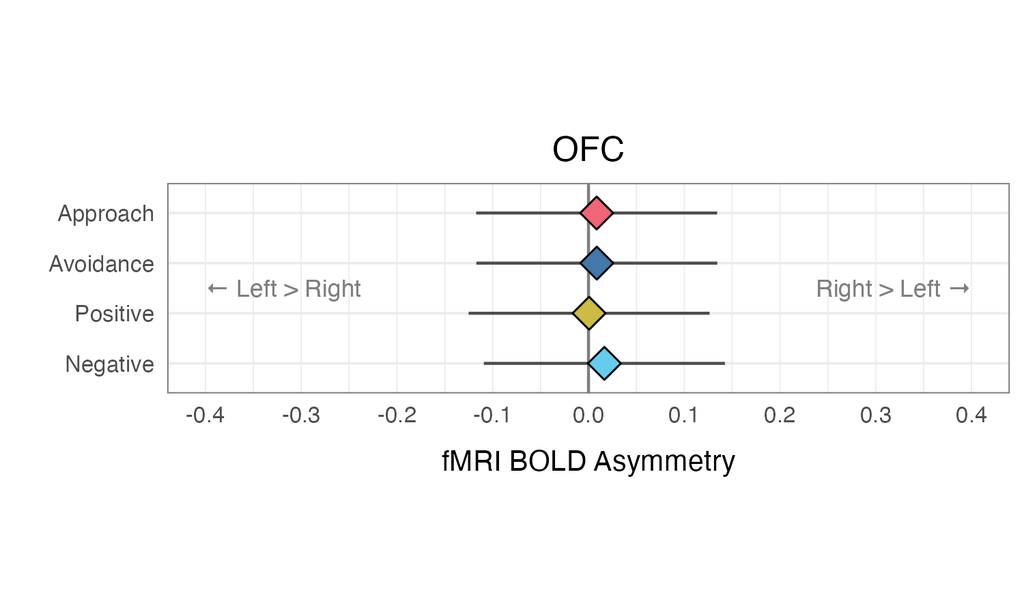

**Plot ROI activation by Side**

#### DLPFC

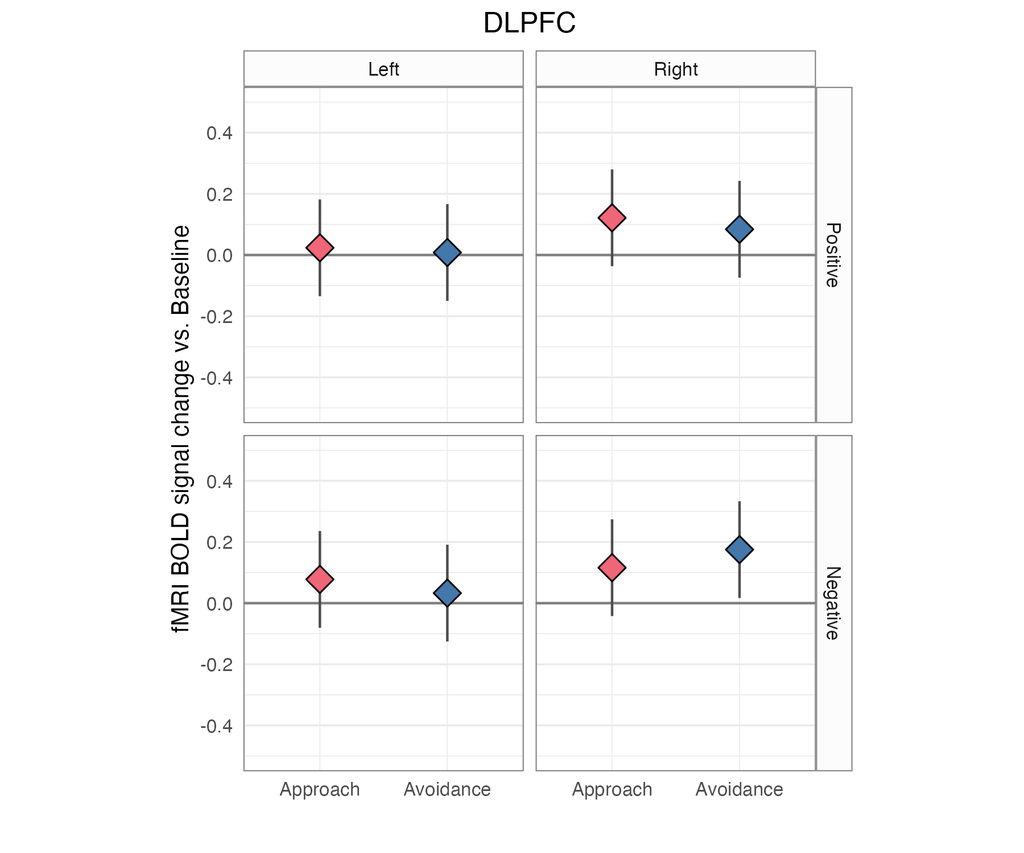

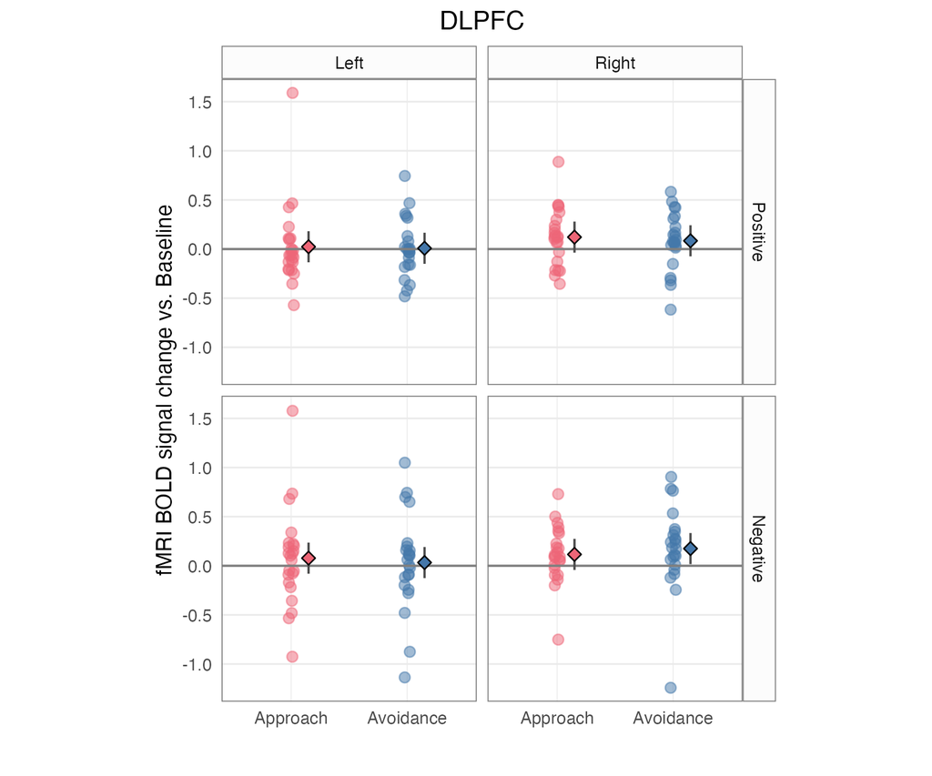

#### OFC

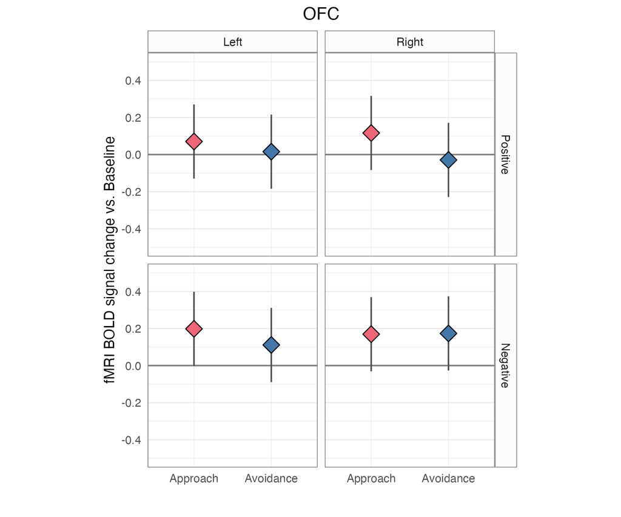

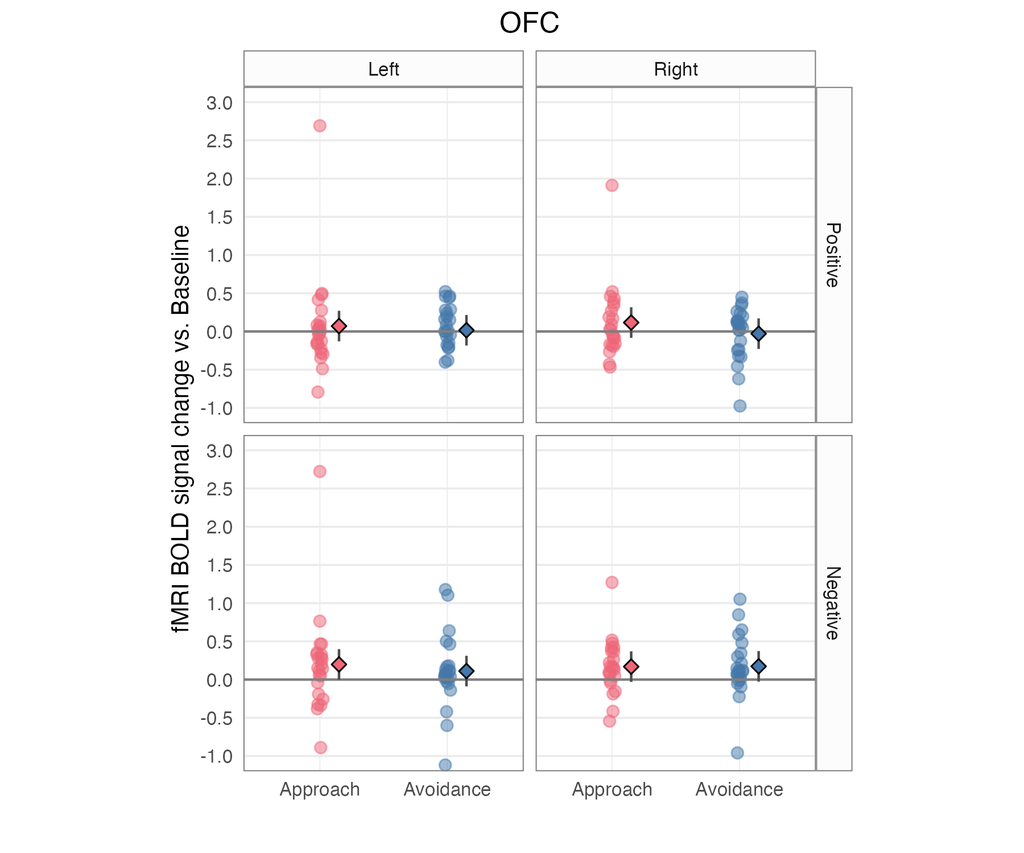